# Assignment 4 - Patrick Torralba

Author

Patrick Torralba

# Preliminary

```r
library(tidyverse) #clean data
library(tidymodels)
library(kableExtra) ## create nice data tables

atus <- read_csv("atus.csv")
```

# Before you begin

**I am selecting SCHAPPY as my outcome**

```r
set.seed(888)

atus_split <- initial_split(
  atus,
  prop = 0.70,
  strata = SCHAPPY
)

atus_train <- training(atus_split)

atus_test <- testing(atus_split)
```

# Question 1

## Define the specs

```r
lin_reg <- linear_reg() |>
  set_engine("glm") |>
  set_mode("regression")
```

## Get all BLS variables

```r
BLS <- atus |>
  select(starts_with("BLS")) |>
  select(1:11)

BLS
```

```
# A tibble: 2,157 × 11
   BLS_CAREHH BLS_CAREHH_ADULT BLS_CAREHH_KID BLS_CAREHH_KIDEDUC
        <dbl>            <dbl>          <dbl>              <dbl>
 1          0                0              0                  0
 2          0                0              0                  0
 3          0                0              0                  0
 4         48                0             45                  0
 5          0                0              0                  0
 6        150                0            150                  0
 7          0                0              0                  0
 8          0                0              0                  0
 9        105                0            105                 45
10          0                0              0                  0
# ℹ 2,147 more rows
# ℹ 7 more variables: BLS_CAREHH_KIDHEALTH <dbl>, BLS_CAREHH_KIDOTHER <dbl>,
#   BLS_CAREHH_TRAVEL <dbl>, BLS_CARENHH <dbl>, BLS_CARENHH_ADULT <dbl>,
#   BLS_CARENHH_ADULTCARE <dbl>, BLS_CARENHH_ADULTHELP <dbl>
```

## Define the model

```r
lin_reg_model <- lin_reg |>
  fit(SCHAPPY ~ BLS_CAREHH +  BLS_CAREHH_ADULT + BLS_CAREHH_KID + BLS_CAREHH_KIDEDUC + BLS_CAREHH_KIDHEALTH + BLS_CAREHH_KIDOTHER + BLS_CAREHH_TRAVEL + BLS_CARENHH + BLS_CARENHH_ADULT + BLS_CARENHH_ADULTHELP,
      data = atus_train)
```

## Predict Probability

```r
predict_lin_reg_model <- predict(lin_reg_model, new_data = atus_test)

## Note to self: only include type = "prob" for classification models
```

## Bind Predictions

```r
atus_pred <- atus_test |>
  bind_cols(predict_lin_reg_model)
```

## Compare Actual vs Predicted SCHAPPY Values

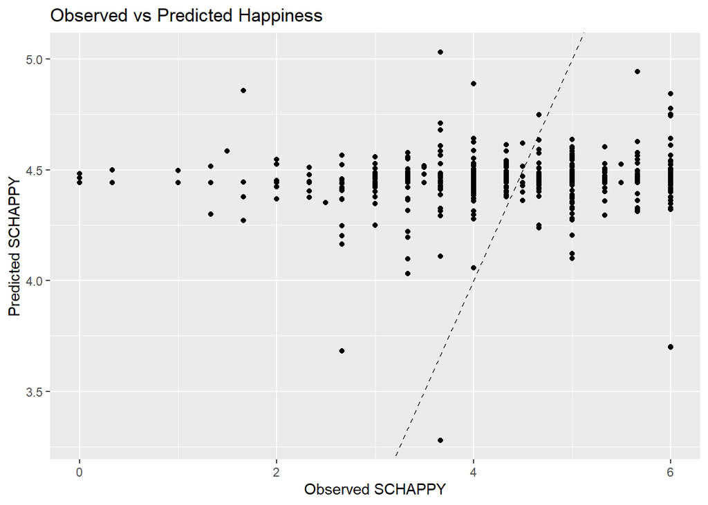

```r
ggplot(atus_pred, aes(x = SCHAPPY, y = .pred)) +
  geom_point() +
  geom_abline(slope = 1, intercept = 0, linetype = "dashed") +
  labs(
    x = "Observed SCHAPPY",
    y = "Predicted SCHAPPY",
    title = "Observed vs Predicted Happiness")
```

## SCHAPPY Table

```r
happy_table <- atus_pred |>
  select(CASEID,BLS_CAREHH, BLS_CAREHH_ADULT,BLS_CAREHH_KID,BLS_CAREHH_KIDEDUC,BLS_CAREHH_KIDHEALTH,BLS_CAREHH_KIDOTHER,BLS_CAREHH_TRAVEL,BLS_CARENHH,BLS_CARENHH_ADULT,BLS_CARENHH_ADULTCARE, BLS_CARENHH_ADULTHELP, SCHAPPY, .pred)

kable(happy_table)
```

| CASEID | BLS_CAREHH | BLS_CAREHH_ADULT | BLS_CAREHH_KID | BLS_CAREHH_KIDEDUC | BLS_CAREHH_KIDHEALTH | BLS_CAREHH_KIDOTHER | BLS_CAREHH_TRAVEL | BLS_CARENHH | BLS_CARENHH_ADULT | BLS_CARENHH_ADULTCARE | BLS_CARENHH_ADULTHELP | SCHAPPY | .pred |
| --- | --- | --- | --- | --- | --- | --- | --- | --- | --- | --- | --- | --- | --- |
| 2.021030e+13 | 0 | 0 | 0 | 0 | 0 | 0 | 0 | 0 | 0 | 0 | 0 | 1.3333333 | 4.442129 |
| 2.021030e+13 | 48 | 0 | 45 | 0 | 0 | 45 | 3 | 0 | 0 | 0 | 0 | 6.0000000 | 4.453649 |
| 2.021030e+13 | 0 | 0 | 0 | 0 | 0 | 0 | 0 | 0 | 0 | 0 | 0 | 4.0000000 | 4.442129 |
| 2.021030e+13 | 0 | 0 | 0 | 0 | 0 | 0 | 0 | 0 | 0 | 0 | 0 | 5.6666667 | 4.442129 |
| 2.021030e+13 | 0 | 0 | 0 | 0 | 0 | 0 | 0 | 0 | 0 | 0 | 0 | 0.3333333 | 4.442129 |
| 2.021030e+13 | 605 | 0 | 590 | 0 | 0 | 590 | 15 | 0 | 0 | 0 | 0 | 5.6666667 | 4.627231 |
| 2.021030e+13 | 5 | 0 | 5 | 0 | 0 | 5 | 0 | 0 | 0 | 0 | 0 | 4.0000000 | 4.443876 |
| 2.021030e+13 | 121 | 0 | 101 | 0 | 0 | 101 | 20 | 0 | 0 | 0 | 0 | 5.6666667 | 4.449414 |
| 2.021030e+13 | 0 | 0 | 0 | 0 | 0 | 0 | 0 | 0 | 0 | 0 | 0 | 5.0000000 | 4.442129 |
| 2.021030e+13 | 0 | 0 | 0 | 0 | 0 | 0 | 0 | 0 | 0 | 0 | 0 | 4.6666667 | 4.442129 |
| 2.021030e+13 | 0 | 0 | 0 | 0 | 0 | 0 | 0 | 0 | 0 | 0 | 0 | 6.0000000 | 4.442129 |
| 2.021030e+13 | 0 | 0 | 0 | 0 | 0 | 0 | 0 | 0 | 0 | 0 | 0 | 4.0000000 | 4.442129 |
| 2.021030e+13 | 5 | 5 | 0 | 0 | 0 | 0 | 0 | 0 | 0 | 0 | 0 | 4.6666667 | 4.439855 |
| 2.021030e+13 | 0 | 0 | 0 | 0 | 0 | 0 | 0 | 0 | 0 | 0 | 0 | 3.6666667 | 4.442129 |
| 2.021030e+13 | 30 | 0 | 30 | 30 | 0 | 0 | 0 | 0 | 0 | 0 | 0 | 3.0000000 | 4.377941 |
| 2.021030e+13 | 80 | 0 | 70 | 0 | 0 | 70 | 10 | 0 | 0 | 0 | 0 | 5.3333333 | 4.452584 |
| 2.021030e+13 | 81 | 0 | 51 | 0 | 0 | 51 | 30 | 25 | 0 | 0 | 0 | 5.3333333 | 4.487551 |
| 2.021030e+13 | 300 | 0 | 240 | 0 | 0 | 240 | 60 | 0 | 0 | 0 | 0 | 6.0000000 | 4.441977 |
| 2.021030e+13 | 7 | 2 | 0 | 0 | 0 | 0 | 5 | 0 | 0 | 0 | 0 | 4.6666667 | 4.434221 |
| 2.021030e+13 | 0 | 0 | 0 | 0 | 0 | 0 | 0 | 0 | 0 | 0 | 0 | 6.0000000 | 4.442129 |
| 2.021030e+13 | 460 | 0 | 370 | 300 | 60 | 10 | 90 | 0 | 0 | 0 | 0 | 6.0000000 | 3.698474 |
| 2.021030e+13 | 30 | 0 | 30 | 30 | 0 | 0 | 0 | 0 | 0 | 0 | 0 | 5.0000000 | 4.377941 |
| 2.021030e+13 | 28 | 0 | 4 | 0 | 0 | 4 | 24 | 0 | 0 | 0 | 0 | 3.6666667 | 4.409931 |
| 2.021030e+13 | 17 | 0 | 2 | 0 | 0 | 2 | 15 | 0 | 0 | 0 | 0 | 3.6666667 | 4.421831 |
| 2.021030e+13 | 190 | 0 | 175 | 0 | 0 | 175 | 15 | 0 | 0 | 0 | 0 | 4.6666667 | 4.482263 |
| 2.021030e+13 | 250 | 0 | 250 | 0 | 0 | 250 | 0 | 0 | 0 | 0 | 0 | 5.6666667 | 4.529459 |
| 2.021030e+13 | 32 | 0 | 32 | 0 | 0 | 32 | 0 | 0 | 0 | 0 | 0 | 2.6666667 | 4.453308 |
| 2.021030e+13 | 0 | 0 | 0 | 0 | 0 | 0 | 0 | 0 | 0 | 0 | 0 | 4.0000000 | 4.442129 |
| 2.021030e+13 | 0 | 0 | 0 | 0 | 0 | 0 | 0 | 0 | 0 | 0 | 0 | 3.6666667 | 4.442129 |
| 2.021030e+13 | 165 | 0 | 120 | 0 | 0 | 120 | 45 | 41 | 0 | 0 | 0 | 4.3333333 | 4.535201 |

[output cut: 619 more lines]

## SCHAPPY Coefficients

```r
coefficients <- lin_reg_model |>
  tidy() |>
  filter(term != "(Intercept)") |>
  mutate(absolute_magnitude = abs(estimate)) |>
  arrange(desc(absolute_magnitude)) |>
  slice_head(n = 10) |>
  select(term, estimate, absolute_magnitude)


kable(coefficients)
```

| term | estimate | absolute_magnitude |
| --- | --- | --- |
| BLS_CARENHH_ADULT | -0.0073699 | 0.0073699 |
| BLS_CARENHH_ADULTHELP | 0.0055404 | 0.0055404 |
| BLS_CAREHH_TRAVEL | -0.0036464 | 0.0036464 |
| BLS_CARENHH | 0.0027840 | 0.0027840 |
| BLS_CAREHH_ADULT | -0.0027014 | 0.0027014 |
| BLS_CAREHH_KIDEDUC | -0.0024889 | 0.0024889 |
| BLS_CAREHH | 0.0022466 | 0.0022466 |
| BLS_CAREHH_KID | -0.0018973 | 0.0018973 |
| BLS_CAREHH_KIDHEALTH | -0.0000040 | 0.0000040 |
| BLS_CAREHH_KIDOTHER | NA | NA |

# Question 2

## Define LASSO spec

```r
lasso_spec <-
  linear_reg(penalty = tune(), mixture = 1) |>
  set_engine("glmnet")
```

## Locate Best Lambda Value by doing Cross-Validation

```r
## Define folds
folds <- vfold_cv(atus_train, v = 5)



## Evaluate different values of lambda
lasso_results <- tune_grid(
  lasso_spec,
  SCHAPPY ~ BLS_CAREHH +  BLS_CAREHH_ADULT + BLS_CAREHH_KID + BLS_CAREHH_KIDEDUC + BLS_CAREHH_KIDHEALTH + BLS_CAREHH_KIDOTHER + BLS_CAREHH_TRAVEL + BLS_CARENHH + BLS_CARENHH_ADULT + BLS_CARENHH_ADULTHELP,
  resamples = folds
)

## Find optimal lambda value. This will be the value with the lowest RMSE value.
best_lambda <- select_best(lasso_results, metric = "rmse")

best_lambda_value <- pull(best_lambda, penalty)
```

**The best lambda value is 0.043 because this has the least root mean squared error value. Meaning that when utilized in a model, it is as close as we can get to the observed values.**

## Define LASSO model

```r
lasso_spec <-
  linear_reg(penalty = best_lambda_value, mixture = 1) |>
  set_engine("glmnet")

lasso_model <- lasso_spec |>
  fit(SCHAPPY ~ BLS_CAREHH +  BLS_CAREHH_ADULT + BLS_CAREHH_KID + BLS_CAREHH_KIDEDUC + BLS_CAREHH_KIDHEALTH + BLS_CAREHH_KIDOTHER + BLS_CAREHH_TRAVEL + BLS_CARENHH + BLS_CARENHH_ADULT + BLS_CARENHH_ADULTHELP,
  data = atus_train)
```

## Predict LASSO Values

```r
predict_lasso_model <- predict(lasso_model, new_data = atus_test)

## Note to self: only include type = "prob" for classification models
```

## Bind LASSO Predictions

```r
lasso_atus_pred <- atus_test |>
  bind_cols(predict_lasso_model)
```

## Compare Actual vs Predicted LASSO SCHAPPY Values

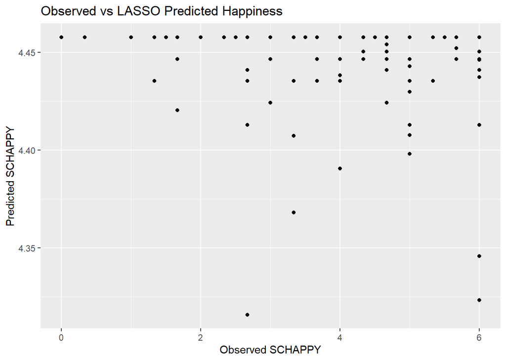

```r
ggplot(lasso_atus_pred, aes(x = SCHAPPY, y = .pred)) +
  geom_point() +
  labs(
    x = "Observed SCHAPPY",
    y = "Predicted SCHAPPY",
       title = "Observed vs LASSO Predicted Happiness")
```

## LASSO SCHAPPY Coefficients

```r
lasso_coefficients <- lasso_model |>
  tidy() |>
  filter(term != "(Intercept)", estimate != 0) |>
  mutate(absolute_magnitude = abs(estimate)) |>
  arrange(desc(absolute_magnitude)) |>
  select(term, estimate)


kable(lasso_coefficients)
```

| term | estimate |
| --- | --- |
| BLS_CAREHH_KIDEDUC | -0.0003737 |

# Question 3

## Compare Coefficients from Linear Regression to Lasso Model

```r
coefficients_comparison <- full_join(coefficients, lasso_coefficients, by = "term") |>
  rename(linear_regression_estimate = estimate.x,
         lasso_estimate = estimate.y)

kable(coefficients_comparison)
```

| term | linear_regression_estimate | absolute_magnitude | lasso_estimate |
| --- | --- | --- | --- |
| BLS_CARENHH_ADULT | -0.0073699 | 0.0073699 | NA |
| BLS_CARENHH_ADULTHELP | 0.0055404 | 0.0055404 | NA |
| BLS_CAREHH_TRAVEL | -0.0036464 | 0.0036464 | NA |
| BLS_CARENHH | 0.0027840 | 0.0027840 | NA |
| BLS_CAREHH_ADULT | -0.0027014 | 0.0027014 | NA |
| BLS_CAREHH_KIDEDUC | -0.0024889 | 0.0024889 | -0.0003737 |
| BLS_CAREHH | 0.0022466 | 0.0022466 | NA |
| BLS_CAREHH_KID | -0.0018973 | 0.0018973 | NA |
| BLS_CAREHH_KIDHEALTH | -0.0000040 | 0.0000040 | NA |
| BLS_CAREHH_KIDOTHER | NA | NA | NA |

## Calculate and Compare Mean-Squared Errors (MSE)

```r
lin_reg_mse <- atus_pred |>
  summarize(
    MSE = mean((SCHAPPY - .pred)^2)
  )

lin_reg_mse
```

```
# A tibble: 1 × 1
    MSE
  <dbl>
1  1.44
```

```r
lasso_mse <- lasso_atus_pred |>
  summarise(
    MSE = mean((SCHAPPY - .pred)^2)
  )

lasso_mse
```

```
# A tibble: 1 × 1
    MSE
  <dbl>
1  1.44
```

It looks like the mean-squared errors of both the linear regression and lasso model are very similar based on the displayed output. Therefore, both models have a very similar predictive performance. However, the linear regression model is slightly better based on it’s lower RMSE value as depicted in Question 4 below. Also, in terms of mean-squared errors, these differences are unlikely to be scientifically relevant due to their highly identical output. For example, lasso MSE could be 1.44 and linear regression MSE could be 1.435, but due to rounding the output would appear as the same value.

# Question 4

## Define two-stage linear regression model

```r
lin_reg_model_v2 <- lin_reg |>
  fit(SCHAPPY ~ BLS_CAREHH_KIDEDUC,
      data = atus_train)
```

## Predictions

```r
two_stage_pred <- predict(lin_reg_model_v2, new_data = atus_test)
```

## Bind Predictions to atus_test

```r
two_stage_atus_pred <- bind_cols(atus_test, two_stage_pred)
```

## Calculate RMSE for two-stage-model

```r
two_stage_rmse <- two_stage_atus_pred |>
  metrics(
    truth = SCHAPPY,
    estimate = .pred
  ) |>
  filter(.metric == "rmse") |>
  mutate(model = "two_stage")


two_stage_rmse
```

```
# A tibble: 1 × 4
  .metric .estimator .estimate model
  <chr>   <chr>          <dbl> <chr>
1 rmse    standard        1.20 two_stage
```

## Compare RMSE with all models

```r
lasso_model_rmse <-  lasso_atus_pred |>
    metrics(
    truth = SCHAPPY,
    estimate = .pred
  ) |>
  filter(.metric == "rmse") |>
    mutate(model = "lasso")


lin_reg_model_rmse <- atus_pred |>
      metrics(
    truth = SCHAPPY,
    estimate = .pred
  ) |>
  filter(.metric == "rmse") |>
    mutate(model = "linear_regression")



models_rmse_compare <- bind_rows(lin_reg_model_rmse, lasso_model_rmse, two_stage_rmse)

kable(models_rmse_compare)
```

| .metric | .estimator | .estimate | model |
| --- | --- | --- | --- |
| rmse | standard | 1.199394 | linear_regression |
| rmse | standard | 1.201227 | lasso |
| rmse | standard | 1.201296 | two_stage |